# Project: Analysis of FBI NICS Background Checks

- Introduction + Imports
- Exploratory Data Analysis
- Question 1
- Question 2
- Notes + References

## Introduction

In part 1, we explored, cleaned up and rebuilt the NICS data. In part 2, we did the same for the census data and created the dataset we'll use to explore the research questions in this section.

This notebook contains part 3, in which we'll explore the various characteristics of states and select some to see how they appear to vary with gun registrations.

The questions we'll address are:

1. Which characteristics of the data appear to be associated with NICS Background Checks?
2. Does a state's voting tendency relate to NICS?

> Imports and data:

```python
# # Imports and files
# Pagckages Import Section
import numpy as np
import pandas as pd
from datetime import datetime
import seaborn as sns
import matplotlib.pyplot as plt
from pprint import pprint

% matplotlib inline

sns.set_style("whitegrid")

# Datasets:
df = pd.read_csv('master_NICS_2011-17.csv')
df.head()
```

|  | Unnamed: 0 | state | pop_16 | pop_10 | pop_chg | foreign_born_pct | owner-occ_housing | med_gross_rent | med_hh_income | no_health_ins | ... | min-owned_prop | politics | handguns_total | long_guns_total | other_total | totals | total_NICS_pc | handguns_pc | long_guns_pc | other_pc |
| --- | --- | --- | --- | --- | --- | --- | --- | --- | --- | --- | --- | --- | --- | --- | --- | --- | --- | --- | --- | --- | --- |
| 0 | 0.0 | Alabama | 4863300.0 | 4780131.0 | 0.017 | 0.035 | 0.687 | 717.0 | 43623.0 | 0.107 | ... | 0.246474 | Red | 135207.0 | 126076.0 | 467577.0 | 3643862 | 0.749257 | 0.027801 | 0.025924 | 0.096144 |
| 1 | 1.0 | Alaska | 741894.0 | 710249.0 | 0.045 | 0.074 | 0.634 | 1146.0 | 72515.0 | 0.155 | ... | 0.201199 | Red | 44639.0 | 43557.0 | 13438.0 | 566738 | 0.763907 | 0.060169 | 0.058711 | 0.018113 |
| 2 | 2.0 | Arizona | 6931071.0 | 6392301.0 | 0.084 | 0.135 | 0.628 | 913.0 | 50255.0 | 0.119 | ... | 0.270666 | Red | 201930.0 | 130644.0 | 188299.0 | 2292122 | 0.330702 | 0.029134 | 0.018849 | 0.027167 |
| 3 | 3.0 | Arkansas | 2988248.0 | 2916025.0 | 0.025 | 0.047 | 0.661 | 677.0 | 41371.0 | 0.093 | ... | 0.155122 | Red | 99117.0 | 113970.0 | 107521.0 | 1651493 | 0.552663 | 0.033169 | 0.038139 | 0.035981 |
| 4 | 4.0 | California | 39250017.0 | 37254522.0 | 0.054 | 0.270 | 0.543 | 1255.0 | 61818.0 | 0.083 | ... | 0.456497 | Blue | 636552.0 | 544564.0 | 1671978.0 | 10186989 | 0.259541 | 0.016218 | 0.013874 | 0.042598 |

5 rows × 24 columns

## Research Questions

### 1. Which characteristics of the data appear to be associated with NICS Background Checks?

We created a dataset with a few economic variables and also variables indicating the proportion of the population who were born in another country.

> Plot the different variables vs. NICS checks per capita:

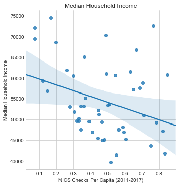

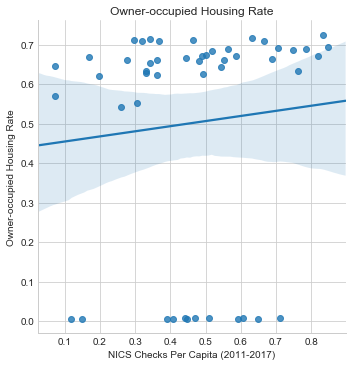

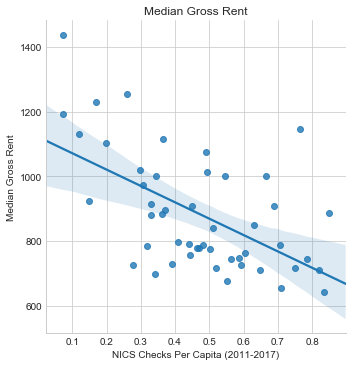

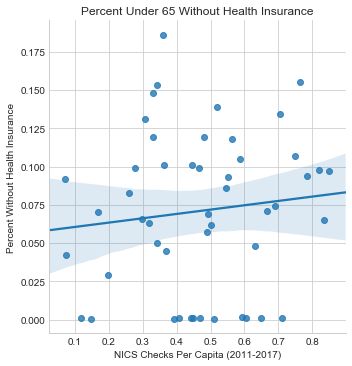

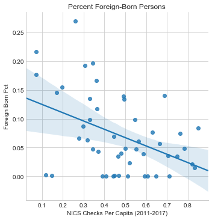

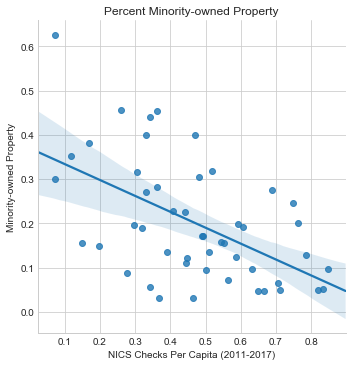

```python
#plot the different variables:

g = sns.lmplot(x='total_NICS_pc', y='med_hh_income', data=df, aspect=1)
g = (g.set_axis_labels('NICS Checks Per Capita (2011-2017)','Median Household Income'))
plt.title("Median Household Income")

h = sns.lmplot(x='total_NICS_pc', y='owner-occ_housing', data=df, aspect = 1)
h = (h.set_axis_labels('NICS Checks Per Capita (2011-2017)','Owner-occupied Housing Rate'))
plt.title("Owner-occupied Housing Rate")

i = sns.lmplot(x='total_NICS_pc', y='med_gross_rent', data=df, aspect=1)
i = (i.set_axis_labels('NICS Checks Per Capita (2011-2017)', 'Median Gross Rent'))
plt.title('Median Gross Rent')

j = sns.lmplot(x='total_NICS_pc', y='no_health_ins', data=df, aspect=1)
j = (j.set_axis_labels('NICS Checks Per Capita (2011-2017)', 'Percent Without Health Insurance'))
plt.title('Percent Under 65 Without Health Insurance')

k = sns.lmplot(x='total_NICS_pc', y='foreign_born_pct', data=df, aspect=1)
k = (k.set_axis_labels('NICS Checks Per Capita (2011-2017)', 'Foreign Born Pct'))
plt.title('Percent Foreign-Born Persons')

m = sns.lmplot(x='total_NICS_pc', y='min-owned_prop', data=df, aspect=1)
m = (m.set_axis_labels('NICS Checks Per Capita (2011-2017)', 'Minority-owned Property'))
plt.title('Percent Minority-owned Property')
plt.show()
```

### Conclusions:

It appears from these EDA visuals that for most states:

1. Fewer NICS checks are done in states with higher proportions of immigrants.
2. States with lower income levels and lower-cost rent on housing have more NICS checks per capita.

It's important to be very careful with how we interpret these visualizations:

- We didn't do a thorough regression analysis, so it's important to point out that these are apparent relationships and not necessarily statistically significant.
- How gun laws are implemented not only varies from state to state, but as we saw in the case of the state of Kentucky, the period from 2010-2011 saw changes in the gun laws that materially impact the number of NICS checks done.
- NICS checks are often used in the media as a loose proxy for how many gun purchases are taking place, but it is only an approximation. Also because NICS checks are not required for private gun sales, actual transactions are almost certain to be higher than the number of NICS checks done.

### 2. Does a state's voting tendency relate to NICS?

> We'll first prep the data and then create a visualization to explore this question:

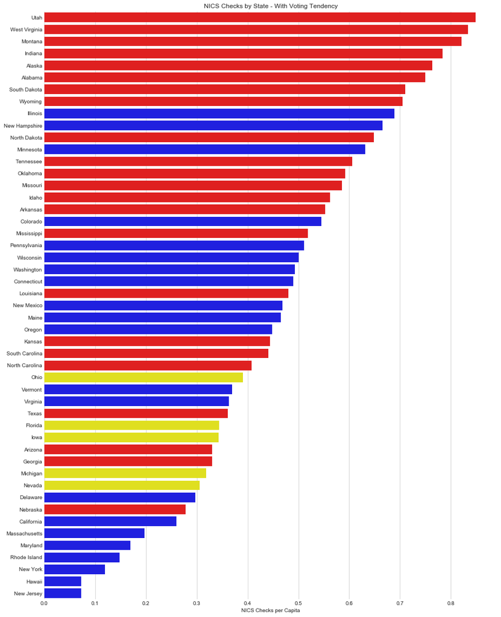

```python
#Prep the data:
df_pols1 = df[['state', 'politics', 'total_NICS_pc']]
df_pols1.dropna(how='any', axis=0, inplace=True)
# Sort the dataframe by the value we want the chart to be sorted by:

df_pols1 = df_pols1.sort_values(['total_NICS_pc'], ascending=[0])

df_pols = pd.DataFrame(df_pols1)

# Add a color column to the data we can use for the visual:
colors = {'Red':'red','Blue':'blue','Swing':'yellow'}
df_pols['color'] = df_pols['politics'].apply(lambda x: colors[x])

# Create visualization:
# Initialize the matplotlib figure
f, ax = plt.subplots(figsize=(15, 20))

sns.barplot(x=df_pols['total_NICS_pc'], y=df_pols['state'], palette=df_pols['color'], data=df_pols)

# Add a legend and informative axis label
plt.title('NICS Checks by State - With Voting Tendency')
ax.legend(loc="lower right", frameon=True)
ax.set(ylabel="",
       xlabel="NICS Checks per Capita")
sns.despine(left=True, bottom=True)
```

## Limitations of the Data and Analysis:

### Data Challenges:

There were a few issues with the data that we should note because they affect the quality of the analysis and reliability of the conclusions we can make:

1. NICS data was provided with annual totals for each state. The Census data were very different - they were aggregated at a specific point in time (usually 2010 and 2016). So for example, using the 2016 population figures to normalize NICS totals from 2010-2016 isn't as precise as using annual population figures.
2. Census data is generally regarded to be highly approximate. Many of the figures are estimates based on samples taken, so while they are likely to be good approximations, it's hard to know how accurate they are.
3. NICS Background check data as a proxy for firearms sales is inherently problematic. There are a few reasons for this:
4. States implement gun laws very differently.
5. Private sales and sales at gun shows don't require background checks.
6. Most states will only do a single check per 30 day period - so one check could apply to multiple sales.
7. The NICS checks numbers reflect the number performed - we don't know how many of them resulted in denials.

I included links in the notes section to more information about NICS as well as additional data that should be taken into consideration.

### Analysis Challenges:

When looking to understand which are the safest states to live in - ie which states is a person least likely to find him/herself in proximity of an armed civilian - just looking at NICS background check data was very challenging for me. As someone who is new to the US and has only lived in countries with very strict gun laws, I had to do a lot of reading just to understand:

- What are the gun control laws in the US? What is governed by federal law vs. state law?
- What is the NICS system, where did it come from and how is it used differently by different states?
- How much impact to changes to state gun laws have on utilization of NICS? This is extremely complex and to add to this complexity - gun laws is an incredibly emotional and heated subject in the US. It is a partisan issue and so media bias is always a possibility.

### Conclusions:

This visualization gives us a pretty clear indication that red states definitely tend to do more gun registrations than blue or swing states.

To remind the reader - it would be a mistake to read too much into this data - for example, guns sold at shows or by private sellers don't necessarily show up in the NICS data at all.

## Notes + References

This section contains notes and links to external references.

#### Notes:

NOTE - We removed Kentucky from the dataset Classification of states by their voting tendency came from Wikipedia

See Notebook 1 for a full list of references.